# README

[Ссылка на репозиторий GitHub](https://github.com/GiproveR/CleaningData)

|  | WebPriceId | DateObserve | StockStatus | CurrentPrice |
| --- | --- | --- | --- | --- |
| 0 | 1 | 2020-06-25 19:23:21.010 | InStock | 49.0 |
| 1 | 1 | 2020-09-08 07:39:23.593 | OutOfStock | NAN |
| 2 | 1 | 2020-09-08 15:39:01.663 | InStock | 49.0 |
| 3 | 1 | 2020-09-08 23:42:25.007 | OutOfStock | NAN |
| 4 | 1 | 2020-09-09 07:38:41.163 | InStock | 49.0 |

# Постановка задачи.

В основе проведенного исследования лежат ежедневные данные по большоме количеству товаров и услуг (более 123 млн ед.) с июня 2020 года по май 2022 года. В роли целевой переменной рассматривается синтетический индекс потребительских цен в формате месяц к месяцу, рассчитанный на основе отдельных позиций ИПЦ Росстата. Для расчёта индекса потребильских цен на отдельные товары используется формула (1):
$$\text{ИПЦ т.} = \frac{P_t}{P_{t-1}},
\tag{1}$$
где $P_t$ - цена на товар/услугу на конец месяца t, $P_{t-1}$ - цена на товар/услугу на конец месяца t-1, для расчёта индекса цен на группу товаров - формула (2) (индекс Карли):
$$\text{ИПЦ гр. т.} =
\frac{\sum_{t=1}^N\text{ИПЦ товара}_i}{N}, \tag{2}$$
где N - количество товаров в группе.

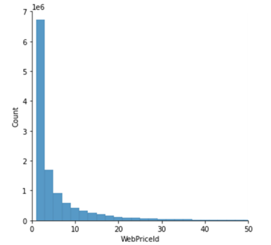

Рис. 1: Гистограмма длины непрерывных рядов наблюдений в исходном наборе данных

# Нанотехнологии

## Нанотехнологии США

В этой области FDA тесно сотрудичает с Национальным институтом стандартов и технологий и Лабораторий характеризации нанотехнологий - (Nanotechnology Characterization Laboratory - NCL) при Национальном институте рака (National Cancer Institute). NCL оказывает поддержку в доклинической характеризации новых лекарственных препаратов (Investigate New Drug - IND), передающихся на рассмотрение и одобрение FDA, и в разработке стандартов и стандартизированных методов измерения наноматерилов, используемых для медицинских целей.

Среди приоритетных целей NCL:

- разработка и стандартизация Аналитического каскада (Assay Cascade Protocols) для характеризации наноматериалов;
- идентификация и характеристика критических параметров связанных с наноматериалами (абсорбция, распределение, метаболизм, выведение и профили токсичности материалов), с использованием моделей животных;
- исследование биологических и функциональных характеристик мультикомпонетных/комбинированных наносодержащих терапевтических средств, молекулярных и клинических диагностикумов для детекции.

## Нанотехнологии России

Российская корпорация нанотехнологий реализует следующие основные функции в сфере нанотехнологий:

1. рассматривает проекты, осуществляет организационную и финансовую поддержку научно-исследовательких и опытно-конструкторских разработок за счёт средств Корпорации;
2. осуществляет финансирование проектов, предусматривающих внедрение нанотехнологий или производство продукции;
3. осуществляет финансирование проектов по подготовке специалистов;
4. осуществляет мониториг реализации проектов, финансируемых за счёт средств Корпорации.

> Федеральная служба по надзору в сфере защиты прав потребитей и благополучия человека (Роспотребнадзор) уделяет серьёзное внимание вопросу регламентации безопасности нанотехнологий и нанопродуктов в России